# Forecasting Green Hydrogen Until 2050

2024-12-06

## Nikhita Kalluri

### NASA Glenn Research Center, Graphics and Visualization Lab

# Abstract

This project aims to predict green hydrogen produced until the year 2050. In order to predict until 2050 for the quantity of green hydrogen that will be produced per year, this forecasting analysis uses the International Energy Agency’s Green Hydrogen dataset which provides information about projects and the corersponding amounts of Hydrogen expected to be produced. An LSTM neural network was chosen due to its ability to handle long-term dependencies in sequential data and capture historical trends for future predictions. The data was scaled and transformed to ensure compatibility with the LSTM model. The neural network was designed with optimized layers tailored for sequential prediction. The model was then trained using the processed time series dataset. A loss function and optimizer were employed to iteratively evaluate and enhance the model’s performance. Forecasting was performed on the training dataset to validate the model’s predictive accuracy. Finally, predictions were generated on the original time series data to forecast green hydrogen production until 2050.

# Introduction

With the accelerating impacts of climate change and the increasing demand for aviation fuel, developing sustainable alternatives has become pertinent. Green hydrogen presents a promising solution as a completely clean source of aviation fuel. However, its widespread adoption faces several challenges, including hydrogen production and availability, storage solutions, fuel and infrastructure costs, technological advancements, and public perception. To explore the potential trajectory of green hydrogen production, it is essential to forecast future trends based on historical data. In this study, we utilize the IEA Green Hydrogen dataset. Key variables of interest include “Date_online,” “Technology_electricity,” “Product,” and “Announced size,” which provide important insights into the production of green hydrogen.

# Methods

## Read in Data

To begin, the dataset is imported as an Excel file and filtered to include only entries labeled as “Dedicated renewable,” as we are focusing exclusively on green hydrogen. Since the volume of hydrogen is presented in varying units, it is necessary to standardize all values to MW for consistent analysis. This standardization is achieved by parsing the units in each observation, applying appropriate conversion factors, and performing the required multiplication or division.

Once the data is standardized, it is summarized by grouping observations by year, ensuring that each year is represented by a single value. This transformation allows for a clearer analysis of trends over time.

```r
# read in and filter dataset by "Dedicated renewable"
df <- read_excel("greenH2Data.xlsx")

filtered_df <- subset(df, Technology_electricity == "Dedicated renewable")
filtered_df
```

```
## # A tibble: 1,292 × 10
##    ProjectName             Country  Date Status Technology `Technology Comments`
##    <chr>                   <chr>   <dbl> <chr>  <chr>      <chr>
##  1 H2GO Energy Park Oude-… NLD      2025 FID/C… Other Ele… Unknown PtX
##  2 H2GO Energy Park Oude-… NLD      2030 Conce… Other Ele… Unknown PtX
##  3 NortH2, phase 1         NLD      2030 Feasi… Other Ele… Unknown PtX
##  4 Norsk e-Fuel Phase 1    NOR      2028 FID/C… SOEC       <NA>
##  5 Norsk e-Fuel Phase 2    NOR      2028 Feasi… SOEC       <NA>
##  6 Iberdrola - Puertollan… ESP      2022 Opera… PEM        <NA>
##  7 Green Hysland Mallorca… ESP      2022 Opera… PEM        <NA>
##  8 Fukushima Hydrogen Ene… JPN      2020 Opera… ALK        <NA>
##  9 Hydrospider - St Gallen CHE      2020 Opera… PEM        <NA>
## 10 Leuchtturmprojekt Powe… DEU      2020 Opera… PEM        <NA>
## # ℹ 1,282 more rows
## # ℹ 4 more variables: Technology_electricity <chr>,
## #   Technology_electricity_details <chr>, Product <chr>, AnnouncedSize <chr>
```

```r
filtered_df <- filtered_df %>%
  filter(!is.na(AnnouncedSize))
```

```r
# Define conversion factors
MW_per_GW <- 1000
MW_per_kW <- 0.001

# Function to handle both power and complex production units
parse_announced_size <- function(entry) {
  # Initialize results list
  result <- list(MW = NA, Production = NA)

  # Check for power units and convert
  if (grepl("GW", entry, ignore.case = TRUE)) {
    result$MW <- as.numeric(str_extract(entry, "^[0-9.]+")) * MW_per_GW
  } else if (grepl("MW", entry, ignore.case = TRUE)) {
    result$MW <- as.numeric(str_extract(entry, "^[0-9.]+"))
  } else if (grepl("kW", entry, ignore.case = TRUE)) {
    result$MW <- as.numeric(str_extract(entry, "^[0-9.]+")) * MW_per_kW
  }

  # Check for production units
  else if (grepl("Nm3/h|Nm³/h|t H2/y|kt H2/y|t H2/d|kg H2/d|million litres per year|litres per year|m3 H2/h|kt NH3/y", entry, ignore.case = TRUE)) {
    result$Production <- entry  # Store entry in Production column

  } else if (grepl("kg H2/y|t MeOH|t NH3|kg H2/d|t H2/y|kt H2/y|kt NH3/y|kt MeOH/y|litres|m3/h|m³/h|t CO2|million litres", entry, ignore.case = TRUE)) {
    result$Production <- entry  # Store entry in Production column

  }

  # Handle ranges (use the lower bound if it's a power unit)
  if (grepl("-", entry) && !is.na(result$MW)) {
    result$MW <- as.numeric(str_extract(entry, "^[0-9.]+"))
  }

  # Return result list with MW and Production columns
  return(result)
}

# Apply parsing function to each entry in AnnouncedSize
parsed_data <- lapply(filtered_df$AnnouncedSize, parse_announced_size)

# Extract MW and Production columns from parsed data
filtered_df$MW <- sapply(parsed_data, function(x) x$MW)
filtered_df$Production <- sapply(parsed_data, function(x) x$Production)

# updated DataFrame
print(filtered_df)
```

```
## # A tibble: 1,198 × 12
##    ProjectName             Country  Date Status Technology `Technology Comments`
##    <chr>                   <chr>   <dbl> <chr>  <chr>      <chr>
##  1 H2GO Energy Park Oude-… NLD      2025 FID/C… Other Ele… Unknown PtX
##  2 H2GO Energy Park Oude-… NLD      2030 Conce… Other Ele… Unknown PtX
##  3 NortH2, phase 1         NLD      2030 Feasi… Other Ele… Unknown PtX
##  4 Norsk e-Fuel Phase 1    NOR      2028 FID/C… SOEC       <NA>
##  5 Norsk e-Fuel Phase 2    NOR      2028 Feasi… SOEC       <NA>
##  6 Iberdrola - Puertollan… ESP      2022 Opera… PEM        <NA>
##  7 Green Hysland Mallorca… ESP      2022 Opera… PEM        <NA>
##  8 Fukushima Hydrogen Ene… JPN      2020 Opera… ALK        <NA>
##  9 Hydrospider - St Gallen CHE      2020 Opera… PEM        <NA>
## 10 Leuchtturmprojekt Powe… DEU      2020 Opera… PEM        <NA>
## # ℹ 1,188 more rows
## # ℹ 6 more variables: Technology_electricity <chr>,
## #   Technology_electricity_details <chr>, Product <chr>, AnnouncedSize <chr>,
## #   MW <dbl>, Production <chr>
```

```r
# Define energy conversion factors
H2_density_kWh_per_Nm3 <- 3.54            # kWh per Nm³ of H2
kerosene_density_kWh_per_litre <- 9.75    # kWh per litre of synthetic kerosene
H2_energy_kWh_per_kg <- 33.33             # kWh per kg of H2
hours_per_year <- 8760                    # hours in a year
days_per_year <- 365                      # days in a year

# Function to convert production to MW equivalent
convert_to_MW <- function(mw, production) {
  # If MW is already present, keep it as is
  if (!is.na(mw)) {
    return(mw)
  }

  # Evaluate which production units
  if (grepl("Nm3/h", production, ignore.case = TRUE)) {
    # Convert Nm³/h of H2 to MW
    rate_Nm3_per_hour <- sum(as.numeric(unlist(str_extract_all(production, "\\d+\\.?\\d*"))))
    mw_equiv <- rate_Nm3_per_hour * H2_density_kWh_per_Nm3 / 1000

  } else if (grepl("million litres per year", production, ignore.case = TRUE)) {
    # Convert million litres per year to MW
    litres_per_year <- as.numeric(str_extract(production, "\\d+\\.?\\d*")) * 1e6
    mw_equiv <- litres_per_year * kerosene_density_kWh_per_litre / (hours_per_year * 1000)

  } else if (grepl("kt H2/y", production, ignore.case = TRUE)) {
    # Convert kilotons per year to MW
    kt_per_year <- as.numeric(str_extract(production, "\\d+\\.?\\d*"))
    mw_equiv <- kt_per_year * 1000 * H2_energy_kWh_per_kg / (hours_per_year * 1000)

  } else if (grepl("t H2/y", production, ignore.case = TRUE)) {
    # Convert tons per year to MW
    tonnes_per_year <- as.numeric(str_extract(production, "\\d+\\.?\\d*"))
    mw_equiv <- tonnes_per_year * H2_energy_kWh_per_kg * 1000 / (hours_per_year * 1000)

  } else if (grepl("t H2/d", production, ignore.case = TRUE)) {
    # Convert tons per day to MW
    tonnes_per_day <- as.numeric(str_extract(production, "\\d+\\.?\\d*"))
    mw_equiv <- tonnes_per_day * H2_energy_kWh_per_kg * 1000 / (24 * 1000)

  } else if (grepl("kg H2/d", production, ignore.case = TRUE)) {
    # Convert kilograms per day to MW
    kg_per_day <- as.numeric(str_extract(production, "\\d+\\.?\\d*"))
    mw_equiv <- kg_per_day * H2_energy_kWh_per_kg / (24 * 1000)

  } else if (grepl("kt NH3/y", production, ignore.case = TRUE)) {
    # Handling ammonia production, placeholder if separate conversion required (adjust accordingly if needed)
    mw_equiv <- NA  # Placeholder, since NH3 requires specific handling not covered here

  } else if (grepl("kW", production, ignore.case = TRUE)) {
    # Convert kW directly to MW
    kw_value <- as.numeric(str_extract(production, "\\d+\\.?\\d*"))
    mw_equiv <- kw_value / 1000

  } else if (grepl("W", production, ignore.case = TRUE) && !grepl("kW", production, ignore.case = TRUE)) {
    # Convert W to MW
    w_value <- as.numeric(str_extract(production, "\\d+\\.?\\d*"))
    mw_equiv <- w_value / 1e6

  } else if (grepl("GW", production, ignore.case = TRUE)) {
    # Convert GW to MW
    gw_value <- as.numeric(str_extract(production, "\\d+\\.?\\d*"))
    mw_equiv <- gw_value * 1000

  } else if (grepl("m3/h", production, ignore.case = TRUE)) {
    # Convert m³/h of H2 to MW (assuming standard m³ density similar to Nm³ for simplicity)
    rate_m3_per_hour <- as.numeric(str_extract(production, "\\d+\\.?\\d*"))
    mw_equiv <- rate_m3_per_hour * H2_density_kWh_per_Nm3 / 1000

  } else if (grepl("litres per year", production, ignore.case = TRUE)) {
    # Convert litres of kerosene per year to MW if not in millions
    litres_per_year <- as.numeric(str_extract(production, "\\d+\\.?\\d*"))
    mw_equiv <- litres_per_year * kerosene_density_kWh_per_litre / (hours_per_year * 1000)

  } else {
    mw_equiv <- NA  # Keep NA if unable to parse
  }

  return(mw_equiv)
}

# Apply conversion function to  dataframe
filtered_df$MW_Equivalent <- mapply(convert_to_MW, filtered_df$MW, filtered_df$Production)

filtered_df
```

```
## # A tibble: 1,198 × 13
##    ProjectName             Country  Date Status Technology `Technology Comments`
##    <chr>                   <chr>   <dbl> <chr>  <chr>      <chr>
##  1 H2GO Energy Park Oude-… NLD      2025 FID/C… Other Ele… Unknown PtX
##  2 H2GO Energy Park Oude-… NLD      2030 Conce… Other Ele… Unknown PtX
##  3 NortH2, phase 1         NLD      2030 Feasi… Other Ele… Unknown PtX
##  4 Norsk e-Fuel Phase 1    NOR      2028 FID/C… SOEC       <NA>
##  5 Norsk e-Fuel Phase 2    NOR      2028 Feasi… SOEC       <NA>
##  6 Iberdrola - Puertollan… ESP      2022 Opera… PEM        <NA>
##  7 Green Hysland Mallorca… ESP      2022 Opera… PEM        <NA>
##  8 Fukushima Hydrogen Ene… JPN      2020 Opera… ALK        <NA>
##  9 Hydrospider - St Gallen CHE      2020 Opera… PEM        <NA>
## 10 Leuchtturmprojekt Powe… DEU      2020 Opera… PEM        <NA>
## # ℹ 1,188 more rows
## # ℹ 7 more variables: Technology_electricity <chr>,
## #   Technology_electricity_details <chr>, Product <chr>, AnnouncedSize <chr>,
## #   MW <dbl>, Production <chr>, MW_Equivalent <dbl>
```

```r
filtered_df <- filtered_df %>%
  filter(!is.na(Date))

filtered_df <- filtered_df %>%
  filter(!is.na(MW_Equivalent))

filtered_df$MW_Equivalent <- as.numeric(filtered_df$MW_Equivalent)
filtered_df$MW_Equivalent <- as.integer(filtered_df$MW_Equivalent)

df = subset(filtered_df, select = c(Date, MW_Equivalent) )

# Summarize data and remove rows where Date is 2043 (NA)
new_dat <- filtered_df %>%
  group_by(Date) %>%
  summarise(MW_Equivalent = mean(MW_Equivalent)) %>%
  filter(Date != 2043)
new_dat
```

```
## # A tibble: 33 × 2
##     Date MW_Equivalent
##    <dbl>         <dbl>
##  1  1965        25
##  2  2000       165
##  3  2007         0
##  4  2008         0
##  5  2010         0
##  6  2012         6
##  7  2013         1
##  8  2014         0
##  9  2015         0.286
## 10  2016         0
## # ℹ 23 more rows
```

Once the dataset is preprocessed and ready to be used, we can understand the distribution of the data visually.

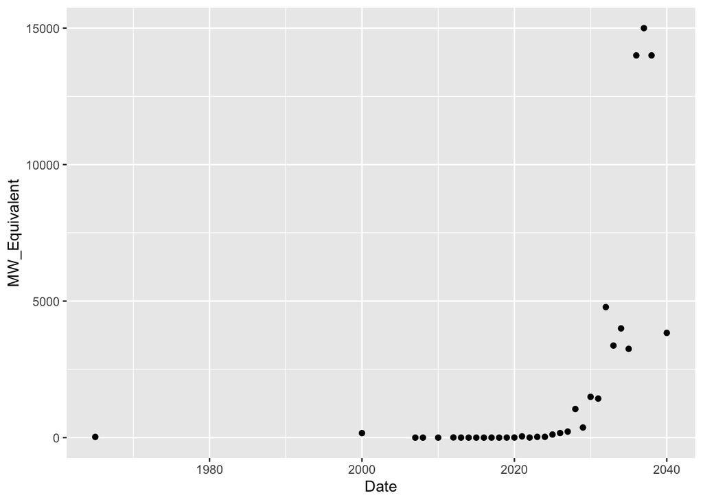

```r
# plot date vs MW
ggplot(new_dat, aes(Date, MW_Equivalent)) +
  geom_point()
```

The plot above shows that the majority of green hydrogen production is concentrated between 2020 and 2040. Additionally, the growth during this period appears to follow an exponential trend. With this, we can proceed to analyze the data for forecasting.

## Data Scaling and Transformation

Now that we have an understanding of the data distribution, we can scale it for compatibility with the LSTM model.

To improve the model’s performance, the data is scaled into a standard normal distribution using the following factors:  
- **scale_factors[1]**: Mean of the `MW_Equivalent` column.  
- **scale_factors[2]**: Standard deviation of the `MW_Equivalent` column.

These factors ensure the data is normalized with a mean of 0 and a standard deviation of 1. Additionally, it is important to verify that the standard deviation is not zero. If it is, the process will end with an error.

```r
# set scale factors to for mean and standard deviation
scale_factors <- c(mean(new_dat$MW_Equivalent), sd(new_dat$MW_Equivalent))
```

```r
# if standard deviation is greater than 0, scale the data - normalization
if (scale_factors[2] > 0) {
  scaled_train <- new_dat %>%
      dplyr::select(MW_Equivalent) %>%
      dplyr::mutate(MW_Equivalent = (MW_Equivalent - scale_factors[1]) / scale_factors[2])
} else {
  stop("Standard deviation is zero or NA. Cannot scale data.")
}
```

With these values defined, we create the `x_train_data` variable, which is a matrix of lag-length sequences. This process generates lagged sequences of input data for the LSTM. The resulting matrix is then converted into a 3D array, as required for LSTM input. The dimensions of this array are `(number of sequences, lag, 1 feature per timestep)`

```r
# set prediction and lag
prediction <- 12
lag <- prediction
```

```r
scaled_train <- as.matrix(scaled_train)
#print(dim(x_train_arr))  # Should match your lag and prediction lengths

# lag the data 11 times and arrange that into columns
x_train_data <- t(sapply(
    1:(length(scaled_train) - lag - prediction + 1),
    function(x) scaled_train[x:(x + lag - 1), 1]
  ))

if (any(is.na(scaled_train)) || any(is.infinite(scaled_train))) {
  stop("Scaled training data contains NA or Inf values.")
}

# transform it into 3D form
x_train_arr <- array(
    data = as.numeric(unlist(x_train_data)),
    dim = c(
        nrow(x_train_data),
        lag,
        1
    )
)
```

Next, we proceed to create the target data, `y_train_arr`, for the LSTM. Each sequence in the `y_train_arr` array contains the prediction values corresponding to the input sequences. Following this, we extract the final prediction values from the dataset to use for testing purposes.

```r
# create the target data array
y_train_data <- t(sapply(
    (1 + lag):(length(scaled_train) - prediction + 1),
    function(x) scaled_train[x:(x + prediction - 1)]
))

y_train_arr <- array(
    data = as.numeric(unlist(y_train_data)),
    dim = c(
        nrow(y_train_data),
        prediction,
        1
    )
)
```

```r
# create x_test by extracting final predictions from dataset
x_test <- new_dat$MW_Equivalent[(nrow(scaled_train) - prediction + 1):nrow(scaled_train)]
x_test
```

```
##  [1]  1048.7647   369.7895  1493.4167  1430.0000  4780.0000  3371.8000
##  [7]  4000.0000  3251.7143 14000.0000 15000.0000 14000.0000  3836.6667
```

In order to have accurate predictions, we need to normalize and reshape the test data as well. The test data is scaled using the same `scale_factors` as the training data and then reshaped into a 3D tensor with a single sample. This process ensures consistency between the training and testing phases.

```r
# scale the data with same scaling factors as for training
x_test_scaled <- (x_test - scale_factors[1]) / scale_factors[2]

if (any(is.na(x_test_scaled)) || any(is.infinite(x_test_scaled))) {
  stop("Test data contains invalid scaled values.")
}
# this time our array just has one sample, as we intend to perform one 12-months prediction
x_pred_arr <- array(
    data = x_test_scaled,
    dim = c(
        1,
        lag,
        1
    )
)
```

## Model Creation

The Long Short-Term Memory model is implemented using the Keras library to predict green hydrogen production. The following steps outline the architecture and setup of the model.

We begin with defining the model architecture. The model includes two LSTM layers, each containing 50 units, or neurons. The input dimensions for the LSTM layers are specified using `batch_input_shape = c(1, 12, 1)`, where the batch size is set to 1—which is required for stateful training, timesteps are set to 12 for lag, and features are set to 1 because there is a single feature—`MW_Equivalent`. The `return_sequences = TRUE` parameter ensures that each LSTM layer outputs a sequence, allowing subsequent layers to process the complete temporal structure while `stateful = TRUE` enables the LSTM to retain memory of current states across batches, which is critical for capturing patterns in sequential data.

To prevent overfitting to training data, dropout layers are included after each LSTM layer, using `layer_dropout(rate = 0.5)`. These layers randomly deactivate 50% of the neurons during training, improving the model’s generalization. Finally, a dense layer, applied to each timestep, outputs a single value for each timestep.

```r
# model creation - 2 layers; batch size 1, 12 timesteps, 1 feature; layer dropout rate- 0.5
lstm_model <- keras_model_sequential() %>%
  layer_lstm(units = 50,
             batch_input_shape = c(1, 12, 1),  # Specify batch_size, timesteps, features
             return_sequences = TRUE,
             stateful = TRUE) %>%
  layer_dropout(rate = 0.5) %>%
  layer_lstm(units = 50,
             return_sequences = TRUE,
             stateful = TRUE) %>%
  layer_dropout(rate = 0.5) %>%
  time_distributed(layer_dense(units = 1))
```

The next step is model compilation. This model uses the Mean Absolute Error as the loss function, which calculates the average absolute difference between the predicted and actual values. This is suitable for continuous data, such as green hydrogen production. For optimization, the Adam optimizer is used. Adam is an algorithm that adjusts learning rates dynamically during training, helping to speed up convergence and improve model performance. Accuracy is included as well as an additional measure of the model’s performance, providing insights into how well the model’s predictions align with the true values.

```r
# compile model using mae, adam optimizer, accuracy as a metric
lstm_model %>%
  compile(loss = 'mae', optimizer = 'adam', metrics = 'accuracy')
```

Now we can display a summary of the model that includes the number of layers, output shapes of each layer, and the total number of trainable parameters.

```r
# generate model sumary
summary(lstm_model)
```

```
## Model: "sequential"
## ________________________________________________________________________________
##  Layer (type)                       Output Shape                    Param #
## ================================================================================
##  lstm_1 (LSTM)                      (1, 12, 50)                     10400
##  dropout_1 (Dropout)                (1, 12, 50)                     0
##  lstm (LSTM)                        (1, 12, 50)                     20200
##  dropout (Dropout)                  (1, 12, 50)                     0
##  time_distributed (TimeDistributed  (1, 12, 1)                      51
##  )
## ================================================================================
## Total params: 30651 (119.73 KB)
## Trainable params: 30651 (119.73 KB)
## Non-trainable params: 0 (0.00 Byte)
## ________________________________________________________________________________
```

The final layer is a time-distributed dense layer that applies a fully connected layer to each timestep independently, producing a single output for each timestep. This layer has 51 parameters, including 50 weights for the 50 units and one bias term. In total, the model has 30,651 parameters, all of which can be trained. We can now move on to the fitting of the model.

## Model Fitting

To fit the model to the training data, the `fit()` function is used. The input data for the model is given by `x_train_arr`, while the target data, or the values the model is predicting, is given by `y_train_arr`. The model is trained with a batch size of 1, meaning that each sequence is individually processed. This is because in stateful LSTM models, it is important to maintain the state across batches. The training process runs for 20 epochs, allowing the model to iterate over the training dataset 20 times to learn the temporal patterns in the data. Additionally, shuffling is disabled, ensuring that the data is processed in sequential order to preserve the state of the LSTM across batches.

```r
# fit model to training data
history <- lstm_model %>% fit(
    x = x_train_arr,
    y = y_train_arr,
    batch_size = 1,
    epochs = 20,
    verbose = 1,
    shuffle = FALSE
)
# extract the MAE values
mae_values <- history$metrics$loss  # 'loss' corresponds to MAE as specified in `compile()`
print(mae_values)
```

```
##  [1] 0.5582039 0.5115816 0.5350297 0.5302113 0.5236734 0.5225841 0.5270997
##  [8] 0.5207757 0.5115904 0.5182607 0.5093948 0.5189766 0.5155879 0.5368251
## [15] 0.5307528 0.5447251 0.5241442 0.5186063 0.5183941 0.5313343
```

## Forecasting and Validation

The forecasting and validation process begins with generating predictions from the trained LSTM model. The model uses the test data given by x_pred_arr to make a forecast, which is done using the predict() function. The predicted values, initially scaled, are stored in the lstm_forecast variable. To transform these predictions back to their original scale, the forecast is multiplied by the standard deviation (scale_factors[2]) and then adding the mean (scale_factors[1]). This process ensures that the forecasted values match the scale of the original data.

```r
lstm_forecast <- lstm_model %>%
    predict(x_pred_arr, batch_size = 1) %>%
    .[, , 1]
```

```
## 1/1 - 1s - 741ms/epoch - 741ms/step
```

```r
# we need to rescale the data to restore the original values
lstm_forecast <- lstm_forecast * scale_factors[2] + scale_factors[1]

if (is.na(scale_factors[1]) || is.na(scale_factors[2]) || scale_factors[2] == 0) {
  stop("Scale factors are invalid. Cannot rescale forecasts.")
}
```

Next, the fitted values, which are the predictions made on the training data, are obtained using the predict() function on x_train_arr. These predictions are initially stored in the fitted variable, and if they have more than one timestep, the values are rearranged to form a continuous sequence. The fitted values are then rescaled to match the original scale of the data, similar to the forecasting step.

```r
# get fitted values using the predict function
 fitted <- predict(lstm_model, x_train_arr, batch_size = 1) %>%
     .[, , 1]
```

```
## 10/10 - 0s - 33ms/epoch - 3ms/step
```

```r
if (dim(fitted)[2] > 1) {
    fit <- c(fitted[, 1], fitted[dim(fitted)[1], 2:dim(fitted)[2]])
} else {
    fit <- fitted[, 1]
}

# additionally we need to rescale the data
fitted <- fit * scale_factors[2] + scale_factors[1]
nrow(fitted)
```

[output not shown]

To ensure that the fitted values align with the length of the dataset, `NA` values are prepended to the beginning of the `fitted` values to match the length of the original training data.

```r
# prepend NA values
fitted <- c(rep(NA, 55), fitted)
fitted
```

```
##  [1]        NA        NA        NA        NA        NA        NA        NA
##  [8]        NA        NA        NA        NA        NA        NA        NA
## [15]        NA        NA        NA        NA        NA        NA        NA
## [22]        NA        NA        NA        NA        NA        NA        NA
## [29]        NA        NA        NA        NA        NA        NA        NA
## [36]        NA        NA        NA        NA        NA        NA        NA
## [43]        NA        NA        NA        NA        NA        NA        NA
## [50]        NA        NA        NA        NA        NA        NA 2962.7506
## [57]  972.2678 1477.4029 1527.9967 1497.0971 1495.4319 1497.4836 1498.0250
## [64] 1501.0622 1505.0202 1504.2951 1502.6047 1500.5824 1498.5874 1497.8011
## [71] 1496.6584 1496.0435 1495.7936 1497.8324 1502.1262 1508.3981
```

The `lstm_forecast` is then converted into a time series object using the `tk_ts()` function from the `timetk` package. The time series is created with a start year of 2040 and an end year of 2051, with a frequency of 1 since it’s annual data. This time series represents the forecasted values for the years 2040 to 2051, which are the years that the model will be forecasting.

```r
# convert values to forecast to a time series object
lstm_forecast <- timetk::tk_ts(lstm_forecast,
    start = c(2040),
    end = c(2051),
    frequency = 1
)
lstm_forecast
```

```
## Time Series:
## Start = 2040
## End = 2051
## Frequency = 1
##  [1] 1455.464 1499.137 1553.790 1606.696 1733.645 1849.034 1960.156 2036.896
##  [9] 2321.880 2683.156 3013.441 3103.314
```

```r
# convert previous values to time series package
input_ts <- timetk::tk_ts(new_dat$MW_Equivalent,
    start = c(1965),
    end = c(2040),
    frequency = 1)
```

The lengths of the original time series data and the fitted values are checked using the length function to ensure that both datasets are compatible in size. The `forecast_list` is then created, which stores the forecasting method (LSTM), the forecasted values (`lstm_forecast`), the original time series data (`input_ts`), the fitted values (`fitted`), and the residuals, calculated as the difference between the original data and the fitted values. These residuals help evaluate the model’s accuracy by measuring the errors in its predictions.

```r
# compare lengths of input and fit to make sure they are equal
length(input_ts)
```

```
## [1] 76
```

```r
length(fitted)
```

```
## [1] 76
```

```r
# generate list of forecasts
forecast_list <- list(
    model = NULL,
    method = "LSTM",
    mean = lstm_forecast,
    x = input_ts,
    fitted = fitted,
    residuals = as.numeric(input_ts) - as.numeric(fitted)
  )

class(forecast_list) <- "forecast"
forecast_list
```

```
##      Point Forecast
## 2040       1455.464
## 2041       1499.137
## 2042       1553.790
## 2043       1606.696
## 2044       1733.645
## 2045       1849.034
## 2046       1960.156
## 2047       2036.896
## 2048       2321.880
## 2049       2683.156
## 2050       3013.441
## 2051       3103.314
```